# Signature Analysis Workflows with sigminer

Signature Analysis Workflows with sigminer A clear illustration Shixiang Wang Tao Wu Ziyu Tao Xue-Song Liu 2020-05-25

This vignette uses a TCGA breast mutation dataset to show how to quickly start analyzing [mutational signatures](https://cancer.sanger.ac.uk/cosmic/signatures) with [{sigminer}](https://cran.r-project.org/web/packages/sigminer/index.html).

## Data Import and Preprocessing

The input data should be in [MAF format](https://docs.gdc.cancer.gov/Data/File_Formats/MAF_Format/), it can be either a MAF file or a `data.frame` in R. Here, we use `{TCGAbiolinks}` package to download TCGA BRCA MAF file as a `data.frame`.

```r
library(TCGAbiolinks)

maf <- GDCquery_Maf("BRCA", pipelines = "mutect2")
save(maf, file = "maf.RData")
```

Then you can transform the data to `MAF` object with `read_maf()`.

```r
library(sigminer)

load("maf.RData")
maf = read_maf(maf)
```

```
#> -Validating
#> -Silent variants: 45177
#> -Summarizing
#> --Possible FLAGS among top ten genes:
#>   TTN
#>   MUC16
#>   HMCN1
#> -Processing clinical data
#> --Missing clinical data
#> -Finished in 10.6s elapsed (9.974s cpu)
```

```r
maf
```

```
#> An object of class  MAF
#>                         ID summary   Mean Median
#>  1:             NCBI_Build  GRCh38     NA     NA
#>  2:                 Center   WUGSC     NA     NA
#>  3:                Samples     986     NA     NA
#>  4:                 nGenes   16131     NA     NA
#>  5:        Frame_Shift_Del    2947  2.992      2
#>  6:        Frame_Shift_Ins    1849  1.877      1
#>  7:           In_Frame_Del     574  0.583      0
#>  8:           In_Frame_Ins     420  0.426      0
#>  9:      Missense_Mutation   62316 63.265     32
#> 10:      Nonsense_Mutation    5734  5.821      2
#> 11:       Nonstop_Mutation      86  0.087      0
#> 12:            Splice_Site    1804  1.831      1
#> 13: Translation_Start_Site      81  0.082      0
#> 14:                  total   75811 76.965     39
```

Next, you need to choose which type of mutational signature you want to analyze, all [COSMIC signatures](https://cancer.sanger.ac.uk/cosmic/signatures) (i.e. SBS, DBS and INDEL) are available.

By calling `sig_tally()` with the following options, you can generate all sample matrices supported by `{sigminer}`.

```r
# Set mode to 'SBS' for SBS only.  Set mode to 'DBS' for DBS only.  Set mode to
# 'ID' for INDEL only.  Set mode to 'ALL' for all types of mutational signatures.
maf_tally <- sig_tally(maf, mode = "ALL", ref_genome = "BSgenome.Hsapiens.UCSC.hg38",
    genome_build = "hg38", use_syn = TRUE, add_trans_bias = TRUE)
```

For a middle-size dataset, this step takes less than 1 minutes.

See the matrix list:

```r
str(maf_tally, max.level = 1)
```

```
#> List of 12
#>  $ SBS_6        : int [1:986, 1:6] 8 16 6 7 4 5 9 4 6 7 ...
#>   ..- attr(*, "dimnames")=List of 2
#>  $ SBS_24       : int [1:986, 1:24] 5 9 3 3 4 1 6 1 4 4 ...
#>   ..- attr(*, "dimnames")=List of 2
#>  $ SBS_96       : int [1:986, 1:96] 1 1 2 1 1 1 0 1 3 1 ...
#>   ..- attr(*, "dimnames")=List of 2
#>  $ SBS_384      : int [1:986, 1:384] 1 1 1 0 1 0 0 0 2 1 ...
#>   ..- attr(*, "dimnames")=List of 2
#>  $ SBS_1536     : int [1:986, 1:1536] 0 0 0 0 0 0 0 0 0 0 ...
#>   ..- attr(*, "dimnames")=List of 2
#>  $ SBS_6144     : int [1:986, 1:6144] 0 0 0 0 0 0 0 0 0 0 ...
#>   ..- attr(*, "dimnames")=List of 2
#>  $ DBS_78       : int [1:986, 1:78] 0 0 0 0 0 0 0 0 0 0 ...
#>   ..- attr(*, "dimnames")=List of 2
#>  $ DBS_186      : int [1:986, 1:186] 0 0 0 0 0 0 0 0 0 0 ...
#>   ..- attr(*, "dimnames")=List of 2
#>  $ ID_28        : int [1:986, 1:28] 0 2 0 0 0 0 1 0 0 0 ...
#>   ..- attr(*, "dimnames")=List of 2
#>  $ ID_83        : int [1:986, 1:83] 0 2 0 0 0 0 1 0 0 0 ...
#>   ..- attr(*, "dimnames")=List of 2
#>  $ ID_415       :'data.frame':   986 obs. of  415 variables:
#>  $ APOBEC_scores:Classes 'data.table' and 'data.frame':  985 obs. of  44 variables:
#>   ..- attr(*, ".internal.selfref")=<externalptr>
#>   ..- attr(*, "index")= int(0)
#>   .. ..- attr(*, "__APOBEC_Enriched")= int [1:985] 121 126 127 136 146 155 160 162 164 165 ...
```

You can also directly use standard sample matrices generated by other tools (like `{sigProfiler}`) or from elsewhere (like a published paper). Just make sure the data are loaded as `matrix` before doing the following analyses.

Now, you can take a look at the catalogues of this breast cancer dataset, e.g. typical 96 lego matrix for SBS mutation:

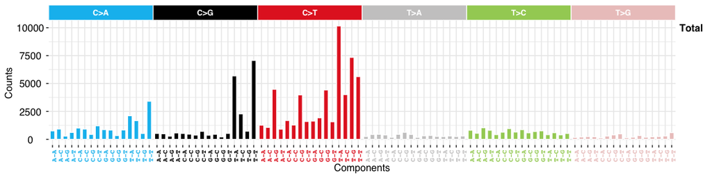

```r
show_catalogue(maf_tally$SBS_96 %>% t(), style = "cosmic")
```

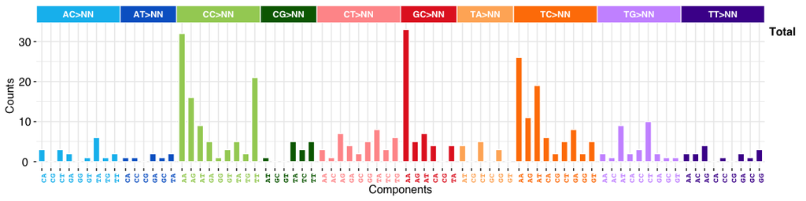

```r
show_catalogue(maf_tally$DBS_78 %>% t(), style = "cosmic", mode = "DBS")
```

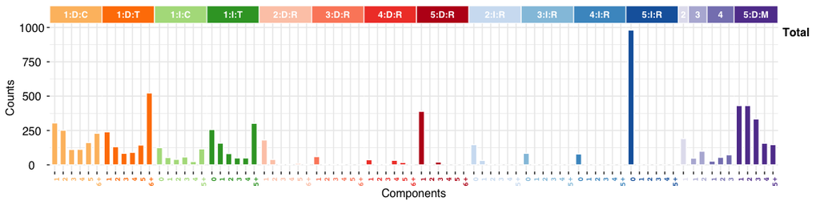

```r
show_catalogue(maf_tally$ID_83 %>% t(), style = "cosmic", mode = "ID")
```

You can also specify a single sample:

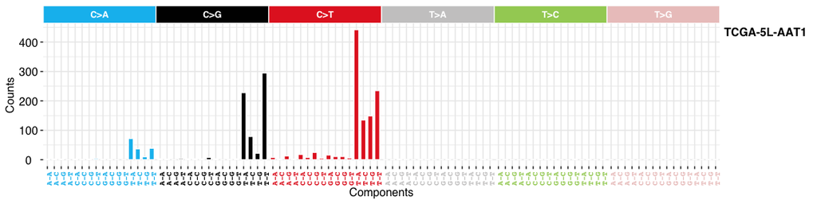

```r
show_catalogue(maf_tally$SBS_96 %>% t(), style = "cosmic", samples = "TCGA-5L-AAT1-01A-12D-A41F-09",
    samples_name = "TCGA-5L-AAT1")
```

## Workflow 1: *de novo* Signatures Discovery

*De novo* signatures discovery can be applied to datasets with abundant mutations.

```r
# SBS
sum(maf_tally$SBS_96)
```

```
#> [1] 112040
```

```r
# DBS
sum(maf_tally$DBS_78)
```

```
#> [1] 367
```

```r
# INDEL
sum(maf_tally$ID_83)
```

```
#> [1] 7858
```

Here we can see that TCGA breast cancers have plents of SBS mutations, we will use SBS as an example, same analysis can be used for DBS and INDEL.

```r
sigs_sbs <- sig_auto_extract(maf_tally$SBS_96, nrun = 10, cores = parallel::detectCores(),
    destdir = "bayesianNMF", result_prefix = "sbs", recover = TRUE)
```

```
#> Recover mode is on, check if all files exist...
#> Yup! Recovering...
#> Select Run 9, which K = 6 as best solution.
```

```r
# recover = TRUE is used to use stored results
```

The `sig_auto_extract()` uses Bayesian NMF to extract mutational signatures through the automatic relevance determination technique (*Kim, Jaegil, et al. “Somatic ERCC2 mutations are associated with a distinct genomic signature in urothelial tumors.” Nature genetics 48.6 (2016): 600.*).

You can also extract specified number of signatures with `sig_extract()`, it use standard NMF algorithms provided by R package [{NMF}](https://cran.r-project.org/web/packages/NMF/index.html) (default is “brunet”). In this way, you need to estimate a proper signature number based on some measures, e.g. cophenetic. You can get measures by running NMF for a range of signature numbers, this is implemented as `sig_estimate()`.

Once you get the signatures, you can show the signature profile with

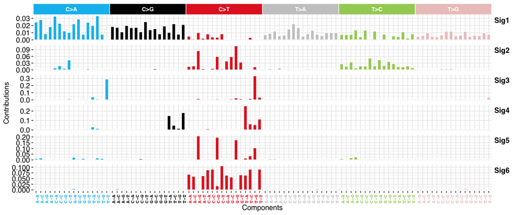

```r
show_sig_profile(sigs_sbs, mode = "SBS", style = "cosmic")
```

Based on COSMIC reference signatures, you can run `get_sig_similarity()` to get the cosine similarity between discovered signatures and COSMIC signatures.

```r
sim <- get_sig_similarity(sigs_sbs, sig_db = "SBS")
```

```
#> -Comparing against COSMIC signatures
#> ------------------------------------
#> --Found Sig1 most similar to SBS3
#>    Aetiology: Defects in DNA-DSB repair by HR [similarity: 0.84]
#> --Found Sig2 most similar to SBS6
#>    Aetiology: defective DNA mismatch repair [similarity: 0.821]
#> --Found Sig3 most similar to SBS10b
#>    Aetiology: Polymerase epsilon exonuclease domain mutations [similarity: 0.84]
#> --Found Sig4 most similar to SBS2
#>    Aetiology: APOBEC Cytidine Deaminase (C>T) [similarity: 0.757]
#> --Found Sig5 most similar to SBS1
#>    Aetiology: spontaneous or enzymatic deamination of 5-methylcytosine [similarity: 0.954]
#> --Found Sig6 most similar to SBS30
#>    Aetiology: deficiency in base excision repair due to inactivating mutations in NTHL1 [similarity: 0.903]
#> ------------------------------------
#> Return result invisiblely.
```

The result returns the best match COSMIC signatures and their etiologies.

This result can be go further plotted by pheatmap.

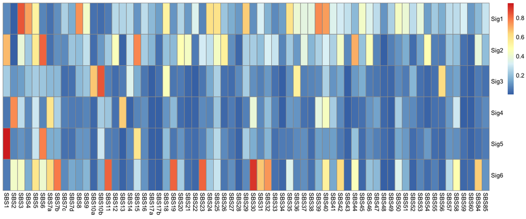

```r
pheatmap::pheatmap(sim$similarity, cluster_cols = F, cluster_rows = F)
```

## Workflow 2: Reference Signatures Fitting

This workflow serves 2 situations:

1. In clinical practice, there are only a few tumor samples or even one tumor sample. You want to get the signature exposures (to judge if a signature exists or to quantify the signature contribution) based on known mutational signatures either from COSMIC database or custom decomposition like workflow 1.
2. You want to optimize signature exposures for signatures defined by workflow 1.

This workflow is implemented as `sig_fit()` (i.e. signature fitting) in `{sigminer}`.

### Single sample

If you only have one sample, you can still use `matrix` format as input. Here we use 30 [COSMIC V2 signatures](https://cancer.sanger.ac.uk/cosmic/signatures_v2) as reference signatures.

```r
one_sample <- sig_fit(catalogue_matrix = maf_tally$SBS_96["TCGA-5L-AAT1-01A-12D-A41F-09",
    , drop = FALSE] %>% t(), sig_index = 1:30, sig_db = "legacy")
one_sample
```

```
#>           TCGA-5L-AAT1-01A-12D-A41F-09
#> COSMIC_1                       106.427
#> COSMIC_2                       792.117
#> COSMIC_3                         0.000
#> COSMIC_4                         0.000
#> COSMIC_5                         0.000
#> COSMIC_6                         0.000
#> COSMIC_7                       177.459
#> COSMIC_8                         0.000
#> COSMIC_9                         0.000
#> COSMIC_10                      141.980
#> COSMIC_11                        0.000
#> COSMIC_12                        0.000
#> COSMIC_13                      710.889
#> COSMIC_14                        0.000
#> COSMIC_15                        0.000
#> COSMIC_16                        0.000
#> COSMIC_17                        0.000
#> COSMIC_18                        0.000
#> COSMIC_19                        0.000
#> COSMIC_20                        0.000
#> COSMIC_21                        0.000
#> COSMIC_22                        0.000
#> COSMIC_23                        0.000
#> COSMIC_24                        7.129
#> COSMIC_25                        0.000
#> COSMIC_26                        0.000
#> COSMIC_27                        0.000
#> COSMIC_28                        0.000
#> COSMIC_29                        0.000
#> COSMIC_30                        0.000
```

If you set a threshold, you can determine if a signature exists in this sample.

```r
one_sample[one_sample > 0, ]
```

```
#>  COSMIC_1  COSMIC_2  COSMIC_7 COSMIC_10 COSMIC_13 COSMIC_24
#>   106.427   792.117   177.459   141.980   710.889     7.129
```

In this situation, relative signature exposures may be more suitable.

```r
one_sample_rel <- sig_fit(catalogue_matrix = maf_tally$SBS_96["TCGA-5L-AAT1-01A-12D-A41F-09",
    , drop = FALSE] %>% t(), sig_index = 1:30, sig_db = "legacy", type = "relative")
one_sample_rel
```

```
#>           TCGA-5L-AAT1-01A-12D-A41F-09
#> COSMIC_1                         0.055
#> COSMIC_2                         0.409
#> COSMIC_3                         0.000
#> COSMIC_4                         0.000
#> COSMIC_5                         0.000
#> COSMIC_6                         0.000
#> COSMIC_7                         0.092
#> COSMIC_8                         0.000
#> COSMIC_9                         0.000
#> COSMIC_10                        0.073
#> COSMIC_11                        0.000
#> COSMIC_12                        0.000
#> COSMIC_13                        0.367
#> COSMIC_14                        0.000
#> COSMIC_15                        0.000
#> COSMIC_16                        0.000
#> COSMIC_17                        0.000
#> COSMIC_18                        0.000
#> COSMIC_19                        0.000
#> COSMIC_20                        0.000
#> COSMIC_21                        0.000
#> COSMIC_22                        0.000
#> COSMIC_23                        0.000
#> COSMIC_24                        0.004
#> COSMIC_25                        0.000
#> COSMIC_26                        0.000
#> COSMIC_27                        0.000
#> COSMIC_28                        0.000
#> COSMIC_29                        0.000
#> COSMIC_30                        0.000
```

A typical cutoff should be set to 0.01 or 0.05.

```r
one_sample_rel[one_sample_rel > 0.05, ]
```

```
#>  COSMIC_1  COSMIC_2  COSMIC_7 COSMIC_10 COSMIC_13
#>     0.055     0.409     0.092     0.073     0.367
```

### Multiple samples

Same usage for multiple samples, here we show head 5 samples.

```r
mul_sample <- sig_fit(catalogue_matrix = maf_tally$SBS_96[1:5, ] %>% t(), sig_index = 1:30,
    sig_db = "legacy")
mul_sample
```

```
#>           TCGA-3C-AAAU-01A-11D-A41F-09 TCGA-3C-AALI-01A-11D-A41F-09
#> COSMIC_1                        17.087                       89.076
#> COSMIC_2                         3.780                      230.567
#> COSMIC_3                         4.920                        2.206
#> COSMIC_4                         0.000                        0.000
#> COSMIC_5                         0.000                        0.000
#> COSMIC_6                         1.255                        0.000
#> COSMIC_7                         0.000                       35.388
#> COSMIC_8                         0.000                        0.000
#> COSMIC_9                         0.000                        0.000
#> COSMIC_10                        1.494                       65.412
#> COSMIC_11                        0.031                        0.000
#> COSMIC_12                        1.710                        0.000
#> COSMIC_13                        0.517                      350.689
#> COSMIC_14                        0.000                        0.000
#> COSMIC_15                        9.048                        0.000
#> COSMIC_16                        0.000                        0.000
#> COSMIC_17                        0.000                        0.000
#> COSMIC_18                        1.588                        0.000
#> COSMIC_19                        0.000                        0.000
#> COSMIC_20                        0.000                        0.000
#> COSMIC_21                        0.000                        0.000
#> COSMIC_22                        0.000                        7.024
#> COSMIC_23                        0.000                        0.000
#> COSMIC_24                        0.000                       11.639
#> COSMIC_25                        0.000                        0.000
#> COSMIC_26                        1.452                        0.000
#> COSMIC_27                        3.946                        0.000
#> COSMIC_28                        0.000                        0.000
#> COSMIC_29                        0.172                        0.000
#> COSMIC_30                        0.000                        0.000
#>           TCGA-3C-AALJ-01A-31D-A41F-09 TCGA-3C-AALK-01A-11D-A41F-09
#> COSMIC_1                        28.617                       12.567
#> COSMIC_2                         0.000                        6.131
#> COSMIC_3                         0.000                        2.290
#> COSMIC_4                         0.000                        0.000
#> COSMIC_5                         2.077                        0.000
#> COSMIC_6                         0.000                       23.213
#> COSMIC_7                         3.434                        0.930
#> COSMIC_8                         0.000                        0.000
```

[output cut: 38 more lines]

```
#> COSMIC_16                        0.885
#> COSMIC_17                        0.000
#> COSMIC_18                        0.000
#> COSMIC_19                        0.000
#> COSMIC_20                        0.000
#> COSMIC_21                        0.000
#> COSMIC_22                        0.000
#> COSMIC_23                        0.000
#> COSMIC_24                        0.574
#> COSMIC_25                        0.000
#> COSMIC_26                        0.000
#> COSMIC_27                        0.605
#> COSMIC_28                        0.000
#> COSMIC_29                        5.339
#> COSMIC_30                        0.000
```

Now, we run all samples and show the result with `show_sig_fit()`.

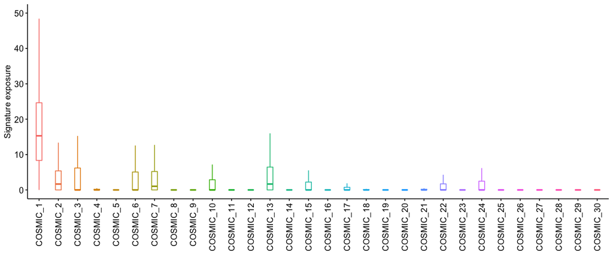

```r
## Outliers are removed.
mul_sample_all <- sig_fit(catalogue_matrix = maf_tally$SBS_96 %>% t(), sig_index = 1:30,
    sig_db = "legacy")
show_sig_fit(mul_sample_all, palette = NULL, add = NULL) + ggpubr::rotate_x_text() +
    ggplot2::ylim(0, 50)
```

Same analysis can be applied to DBS and INDEL. This dataset also has plents of INDELs, you can take a try.

Firstly check valid COSMIC INDEL signature indices if you are not familiar with.

```r
show_cosmic_sig_profile(sig_db = "ID")
```

```r
mul_sample_id <- sig_fit(catalogue_matrix = maf_tally$ID_83[1:4, ] %>% t(), sig_index = 1:11,
    sig_db = "ID")
mul_sample_id
```

```
#>      TCGA-3C-AAAU-01A-11D-A41F-09 TCGA-3C-AALI-01A-11D-A41F-09
#> ID1                         2.426                        0.000
#> ID2                         0.000                        0.000
#> ID3                         0.000                        0.000
#> ID4                         0.000                        0.847
#> ID5                         0.935                        0.000
#> ID6                         0.293                        0.231
#> ID7                         0.000                        1.957
#> ID8                         0.000                        2.016
#> ID9                         0.000                        5.281
#> ID10                        5.346                        1.868
#> ID11                        0.000                        0.801
#>      TCGA-3C-AALJ-01A-31D-A41F-09 TCGA-3C-AALK-01A-11D-A41F-09
#> ID1                         0.000                        1.386
#> ID2                         0.000                        0.000
#> ID3                         0.000                        0.000
#> ID4                         0.000                        0.642
#> ID5                         7.260                        2.972
#> ID6                         1.071                        0.000
#> ID7                         0.000                        0.000
#> ID8                         2.668                        0.000
#> ID9                         0.000                        0.000
#> ID10                        0.000                        0.000
#> ID11                        0.000                        0.000
```

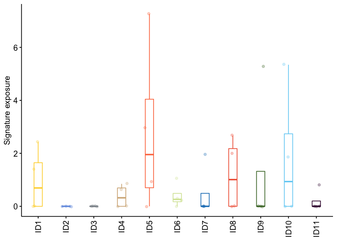

```r
show_sig_fit(mul_sample_id, palette = "simpsons") + ggpubr::rotate_x_text()
```

If you want to optimize exposures for signatures obtained from workflow 1, run the following command.

```r
mul_sample_custom <- sig_fit(catalogue_matrix = maf_tally$SBS_96[1:5, ] %>% t(),
    sig = sigs_sbs)
mul_sample_custom
```

```
#>      TCGA-3C-AAAU-01A-11D-A41F-09 TCGA-3C-AALI-01A-11D-A41F-09
#> Sig1                        8.478                      109.713
#> Sig2                       15.451                        2.870
#> Sig3                        2.958                       64.553
#> Sig4                        4.327                      583.795
#> Sig5                        9.725                       31.068
#> Sig6                        6.061                        0.000
#>      TCGA-3C-AALJ-01A-31D-A41F-09 TCGA-3C-AALK-01A-11D-A41F-09
#> Sig1                       17.764                        7.638
#> Sig2                        5.689                       17.753
#> Sig3                        1.396                        5.363
#> Sig4                        4.452                        9.255
#> Sig5                       17.384                       15.273
#> Sig6                        9.315                       10.718
#>      TCGA-4H-AAAK-01A-12D-A41F-09
#> Sig1                        7.948
#> Sig2                       10.355
#> Sig3                        5.763
#> Sig4                        0.000
#> Sig5                        9.188
#> Sig6                        1.746
```

## Contact

- Xue-Song Liu: liuxs@shanghaitech.edu.cn
- Shixiang Wang: wangshx@shanghaitech.edu.cn